# Election Prediction Model

# Why do we want to study it?

- It is an example of an influential applied Bayesian statistic work
- This model has complete code with every details and tons of discussion on Andrew Gelman’s blog by himself and his followers (of which many are statisticians).
- This model use informative prior, which are different from textbook very weak priors.
- It’s good to compare the difference with other prediction model on market.
  - Economist
  - Silver Bulletin
  - FiveThirtyEight
- Its performance can be tested soon

# Problem:

- Goal:
  - Estimate the proportion of people in each state supporting trump in the presidential election along with uncertainty quantification.
  - Simulate the distribution of total electoral votes in the final election and calculate the probability that Trump wins.
- Data: polls, economic, etc..
- Expectation: Result should be reasonable.
  - Reasonable point estimate
  - Reasonably confidence interval

## Reading data

```r
library(dplyr)
library(lqmm)
poll <- read.csv("https://projects.fivethirtyeight.com/polls/data/president_polls.csv")
poll <- poll[,c(1,3,11,13,15,22,23,26,47:51)]
poll <- poll[!duplicated(poll),]

poll$state[which(poll$state == "Maine CD-1")] <- "Maine"
poll$state[which(poll$state == "Maine CD-2")] <- "Maine"
poll$state[which(poll$state == "Nebraska CD-2")] <- "Nebraska"

#read Cov state matrix
Cov.state <- readRDS("Cov.state.RDS")
#Cholesky decompose
Cho.Cov.state <- chol(Cov.state)

# filter the data
poll <- poll %>%
  mutate(end_date = as.Date(poll$end_date,"%m/%d/%y")) %>%
  filter(end_date > as.Date("2024-07-28","%Y-%m-%d"))
quetion_id_tb <- table(poll$question_id)

# remove 4 candidates results
quetion_id_filter <- names(quetion_id_tb)[quetion_id_tb==2]

poll <- poll %>% filter(question_id %in% quetion_id_filter)

# if both type of voters exist, only take likely voters

filtered_poll <- poll %>%
  group_by(poll_id) %>%
  # For each poll_id, check if "lv" is not the only population_full present
  mutate(has_lv = any(population_full == "lv")) %>%
  # Filter: if there are non-lv values, keep only rows where population_full == "lv"
  filter(!has_lv | population_full == "lv") %>%
  # Drop the helper column
  select(-has_lv)

filtered_poll <- filtered_poll %>%
  group_by(poll_id) %>%
  # For each poll_id, check if "lv" is not the only population_full present
  mutate(has_rv = any(population_full == "rv")) %>%
  # Filter: if there are non-lv values, keep only rows where population_full == "lv"
  filter(!has_rv | population_full == "rv") %>%
  # Drop the helper column
  select(-has_rv)
# remove other candidates

filtered_poll <- filtered_poll %>% filter(candidate_name%in%c("Donald Trump","Kamala Harris"))
filtered_poll <- filtered_poll[!duplicated(filtered_poll),]

# only keep the first 2
filtered_poll <- filtered_poll %>%
  group_by(poll_id) %>%
  slice(1:2) %>%  # Keep only the first 2 rows per group (poll_id)
  ungroup()       # Ungroup the data


# construct data for modelling

adjusted_poll <- filtered_poll %>%
  group_by(poll_id) %>%
  mutate(
    # Sum of pct for each poll_id
    total_pct = sum(pct),

    # If total_pct is not 100, adjust percentages and sample size
    pct = ifelse(total_pct != 100, (pct / total_pct) * 100, pct),

    # Adjust the sample size proportionally if total_pct is not 100
    new_sample_size = ifelse(total_pct != 100, round(sample_size * total_pct / 100), sample_size),

    trump_vote = round(new_sample_size* pct/100)
  ) %>%
  ungroup() %>%  # Remove grouping
  filter(candidate_name=="Donald Trump") %>%
  select(-total_pct)  # Remove the helper column


final_poll <- adjusted_poll %>% select(-c(6,9,10,12)) %>%
  mutate(state=ifelse(state=="","National",state)) %>%
  filter(!is.na(sample_size))

origin_data <- as.Date("2024-07-28")
# Create unique IDs for states and days
final_poll <- final_poll %>%
  mutate(
    state_id = as.numeric(factor(state)),
    day_id = as.numeric(end_date-origin_data)
  )

state_tb <- 1:39
names(state_tb) <- levels(factor(final_poll$state))

remove(adjusted_poll,filtered_poll)
head(final_poll)
```

| poll_id | pollster | methodology | state | end_date | sample_size | population_full | candidate_id | pct | new_sample_size | trump_vote | state_id | day_id |
| --- | --- | --- | --- | --- | --- | --- | --- | --- | --- | --- | --- | --- |
| 87631 | PPP |  | Arizona | 2024-07-30 | 618 | rv | 16651 | 51.04167 | 593 | 303 | 2 | 2 |
| 87632 | PPP |  | Pennsylvania | 2024-07-30 | 627 | rv | 16651 | 50.52632 | 596 | 301 | 29 | 2 |
| 87633 | PPP |  | Georgia | 2024-07-30 | 662 | rv | 16651 | 49.47368 | 629 | 311 | 7 | 2 |
| 87639 | ActiVote | App Panel | National | 2024-07-29 | 1000 | lv | 16651 | 51.30000 | 1000 | 513 | 18 | 1 |
| 87640 | McLaughlin | Online Panel | National | 2024-07-29 | 1000 | lv | 16651 | 51.08696 | 920 | 470 | 18 | 1 |
| 87641 | Civiqs | Online Panel | National | 2024-07-30 | 1123 | rv | 16651 | 47.87234 | 1056 | 506 | 18 | 2 |

```r
library(ggplot2)


#Covariance of State
state_data_long <- readRDS(file = "state_data_long.RDS")

state_data_long <- state_data_long[, colnames(state_data_long) %in% names(state_tb)]
C <- cor(state_data_long)
C[C < 0] <- 0 # baseline cor for national poll error


tmp_C <- C
diag(tmp_C) <- NA
mean(tmp_C,na.rm=T)
```

```
## [1] 0.4760156
```

```r
# mixing with matrix of 0.5s
lambda <- 0.75
C_1 <- matrix(data=1,nrow = nrow(C),ncol=ncol(C))
a <- 1
new_C <- (lambda*C + (1-lambda)*C_1) %>% make.positive.definite()

tmp <- new_C
diag(tmp) <- NA
mean(tmp,na.rm=T)
```

```
## [1] 0.6062779
```

```r
#state_correlation_polling <- new_C

C_0.6 <- 0.6 * C
diag(C_0.6) <- 1
state_correlation_polling <- C_0.6 %>% make.positive.definite()

# make pos definite
state_correlation_polling <- make.positive.definite(state_correlation_polling)

dim(state_correlation_polling)
```

```
## [1] 39 39
```

```r
Cov.state <- diag(0.1,ncol(state_correlation_polling)) %*% state_correlation_polling %*% diag(0.1,ncol(state_correlation_polling))

Cho.Cov.state <- chol(Cov.state)
```

# Simple Binomial Modelling

```r
library(rstan)
options(mc.cores = 4)
setwd("~/BDA")
# Prepare the data list for Stan


stan_data <- list(
  N = nrow(final_poll),                  # Number of observations
  S = length(state_tb),  # Number of unique states
  D = max(final_poll$day_id),  # Number of unique days
  sample_size = final_poll$new_sample_size,  # Sample size for each observation
  trump_vote = final_poll$trump_vote,    # Trump votes for each observation
  state_id = final_poll$state_id,        # State index for each observation
  day_id = final_poll$day_id             # Day index for each observation
)

fit_binom1 <- stan(
  file = "Election_model1.stan",  # Stan program
  data = stan_data,    # named list of data
  chains = 4,             # number of Markov chains
  warmup = 1000,          # number of warmup iterations per chain
  iter = 4000,            # total number of iterations per chain
  refresh = 0             # no progress shown

)
```

```
## Trying to compile a simple C file
```

[output not shown]

```r
print(fit_binom1, pars = c("p"))
```

[output not shown]

[output not shown]

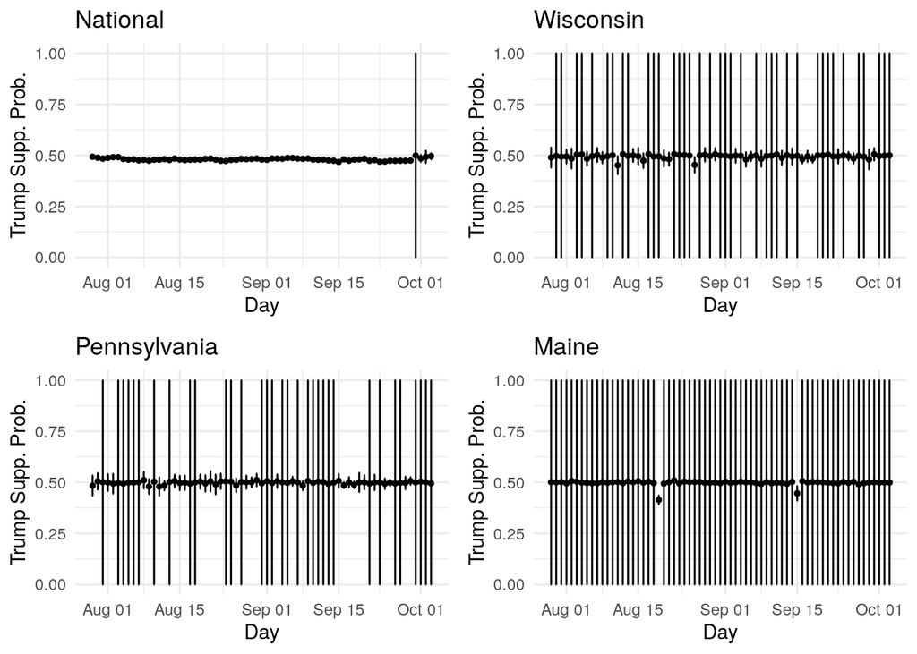

```r
post_prob <- extract(fit_binom1)
post_p_mat <- post_prob$p
plot_model <- function(post_prob,final_poll,state="National"){
  state_id <- which(names(state_tb)==state)
  low <- apply(post_p_mat[,state_id,],2,quantile,0.025)
  high <- apply(post_p_mat[,state_id,],2,quantile,0.975)
  mean <- apply(post_p_mat[,state_id,],2,mean)

plot_data <- data.frame(

  day =   as.Date(1:max(final_poll$day_id),origin="2024-07-28"),
  mean = mean,
  low = low,
  high = high
)

# Plot the data using ggplot2
p <- ggplot(plot_data, aes(x = day, y = mean)) +
  geom_point(size = 1) +  # Dots for mean values
  geom_errorbar(aes(ymin = low, ymax = high), width = 0.2) +  # Error bars
  labs(
    title = state,
    x = "Day",
    y = "Trump Supp. Prob."
  ) +
  theme_minimal()  # Minimal theme for clean appearance
  return(p)
}

p1 <- plot_model(post_prob,final_poll,state="National")
p2 <- plot_model(post_prob,final_poll,state="Wisconsin")
p3 <- plot_model(post_prob,final_poll,state="Pennsylvania")
p4 <- plot_model(post_prob,final_poll,state="Maine")

gridExtra::grid.arrange(p1,p2,p3,p4,ncol=2)
```

# Binomial Modelling - assuming probability has random walk prior

```r
stan_data <- list(
  N = nrow(final_poll),                  # Number of observations
  S = length(state_tb),  # Number of unique states
  T = max(final_poll$day_id),  # Number of unique days
  sample_size = final_poll$new_sample_size,  # Sample size for each observation
  trump_vote = final_poll$trump_vote,    # Trump votes for each observation
  state_id = final_poll$state_id,        # State index for each observation
  day_id = final_poll$day_id             # Day index for each observation
)

fit_binom2 <- stan(
  file = "Election_model4.stan",  # Stan program
  data = stan_data,    # named list of data
  chains = 4,             # number of Markov chains
  warmup = 1000,          # number of warmup iterations per chain
  iter = 2000,            # total number of iterations per chain
  refresh = 0             # no progress shown
)
```

```
## Trying to compile a simple C file
```

[output not shown]

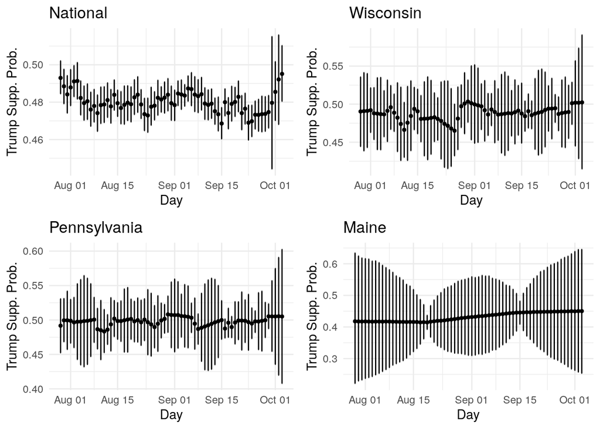

```r
#print(fit_binom3, pars = c("p"))

post_prob <- extract(fit_binom2)
post_p_mat <- post_prob$p
plot_model <- function(post_prob,final_poll,state="National"){
  state_id <- which(names(state_tb)==state)
  low <- apply(post_p_mat[,state_id,],2,quantile,0.025)
  high <- apply(post_p_mat[,state_id,],2,quantile,0.975)
  mean <- apply(post_p_mat[,state_id,],2,mean)

plot_data <- data.frame(

  day =   as.Date(1:max(final_poll$day_id),origin="2024-07-28"),
  mean = mean,
  low = low,
  high = high
)

# Plot the data using ggplot2
p <- ggplot(plot_data, aes(x = day, y = mean)) +
  geom_point(size = 1) +  # Dots for mean values
  geom_errorbar(aes(ymin = low, ymax = high), width = 0.2) +  # Error bars
  labs(
    title = state,
    x = "Day",
    y = "Trump Supp. Prob."
  ) +
  theme_minimal()  # Minimal theme for clean appearance
  return(p)
}

p1 <- plot_model(post_prob,final_poll,state="National")
p2 <- plot_model(post_prob,final_poll,state="Wisconsin")
p3 <- plot_model(post_prob,final_poll,state="Pennsylvania")
p4 <- plot_model(post_prob,final_poll,state="Maine")

gridExtra::grid.arrange(p1,p2,p3,p4,ncol=2)
```

Variables used to compute covariance matrix between states:

2016: Percentage of the vote that the Democrat candidate received in the 2016 U.S. presidential election.

white_pct: Percentage of the population that identified as white in 2013.

black_pct: Percentage of the population that identified as Black or African American in 2013.

hisp_other_pct: Percentage of the population that identified as Hispanic or from other racial/ethnic backgrounds in 2013.

college_pct: Percentage of the population aged 25 and older with a college degree or higher in 2013.

wwc_pct: Percentage of the population that is white and working-class (non-college-educated).

median_age: Median age of the population in 2013.

pop_density: Population density measured in people per square mile in 2013.

pct_white_evangel: Percentage of the population that identifies as white evangelical Christians, typically based on data from around 2013 or similar years.

Add state correlation

```r
stan_data <- list(
  N = nrow(final_poll),                  # Number of observations
  S = length(state_tb),  # Number of unique states
  T = max(final_poll$day_id),  # Number of unique days
  sample_size = final_poll$new_sample_size,  # Sample size for each observation
  trump_vote = final_poll$trump_vote,    # Trump votes for each observation
  state_id = final_poll$state_id,        # State index for each observation
  day_id = final_poll$day_id,             # Day index for each observation
  cho_state_covariance = Cho.Cov.state
)

fit_binom3 <- stan(
  file = "Election_model5.stan",  # Stan program
  data = stan_data,    # named list of data
  chains = 4,             # number of Markov chains
  warmup = 1000,          # number of warmup iterations per chain
  iter = 2000,            # total number of iterations per chain
  refresh = 0            # no progress shown
)
```

```
## Trying to compile a simple C file
```

[output not shown]

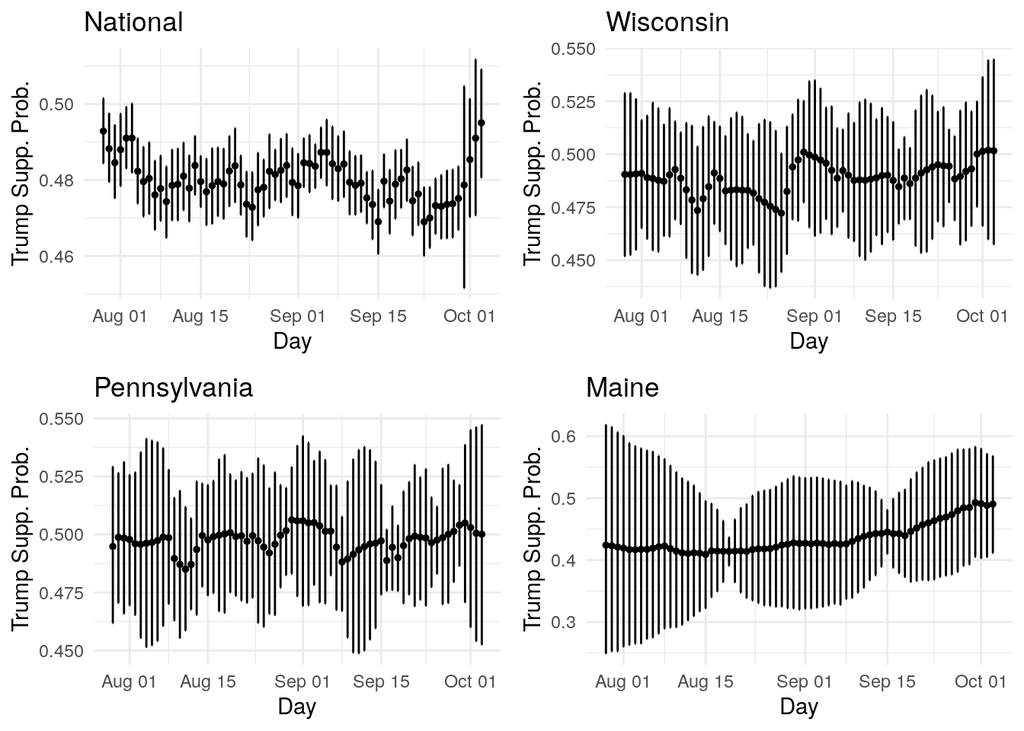

```r
#print(fit_binom3, pars = c("p"))

post_prob <- extract(fit_binom3)
post_p_mat <- post_prob$p
plot_model <- function(post_prob,final_poll,state="National"){
  state_id <- which(names(state_tb)==state)
  low <- apply(post_p_mat[,state_id,],2,quantile,0.025)
  high <- apply(post_p_mat[,state_id,],2,quantile,0.975)
  mean <- apply(post_p_mat[,state_id,],2,mean)

plot_data <- data.frame(

  day =   as.Date(1:max(final_poll$day_id),origin="2024-07-28"),
  mean = mean,
  low = low,
  high = high
)

# Plot the data using ggplot2
p <- ggplot(plot_data, aes(x = day, y = mean)) +
  geom_point(size = 1) +  # Dots for mean values
  geom_errorbar(aes(ymin = low, ymax = high), width = 0.2) +  # Error bars
  labs(
    title = state,
    x = "Day",
    y = "Trump Supp. Prob."
  ) +
  theme_minimal()  # Minimal theme for clean appearance
  return(p)
}

p1 <- plot_model(post_prob,final_poll,state="National")
p2 <- plot_model(post_prob,final_poll,state="Wisconsin")
p3 <- plot_model(post_prob,final_poll,state="Pennsylvania")
p4 <- plot_model(post_prob,final_poll,state="Maine")

gridExtra::grid.arrange(p1,p2,p3,p4,ncol=2)
```